# Hacklab Developer Census 2020

# Basic Information

## What describes you best?

The two biggest subgroups among the respondents are professional developers as well as students. Additionally, there are respondents coding as a part of their work, coding as a hobby, as well as former developers.

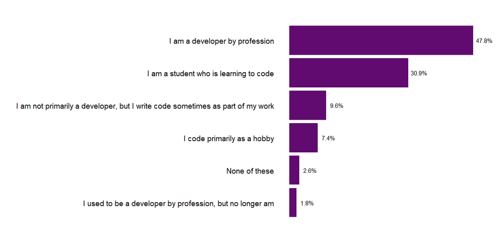

## Do you code as a hobby?

Most of the respondents code as a hobby. Interestingly, professional developers seem to code for a hobby less often than students which may be related to their reduced time availability.

### All Respondents

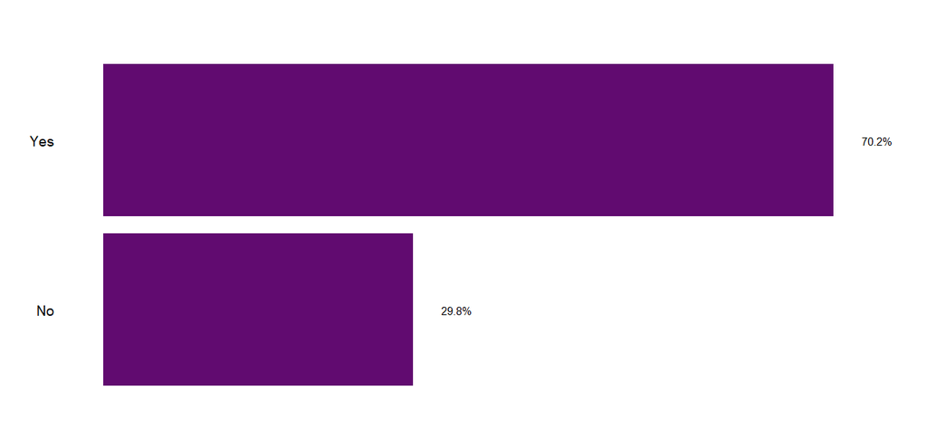

### Professional Developers

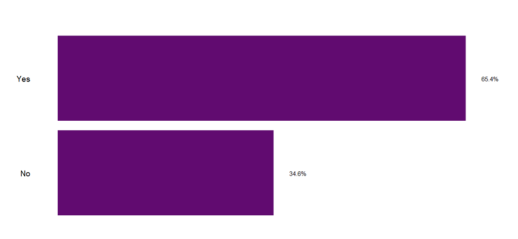

### Students

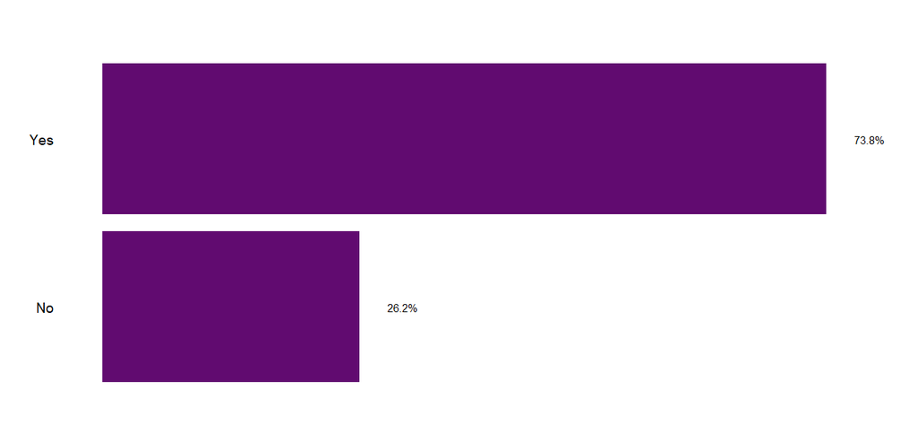

## Employment

When it comes to gender differences, there is a greater share of students among the female respondents. In addition, women seem to be self-employed less often when compared with men.

### All Respondents

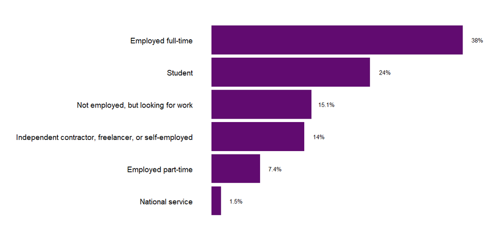

### Men only

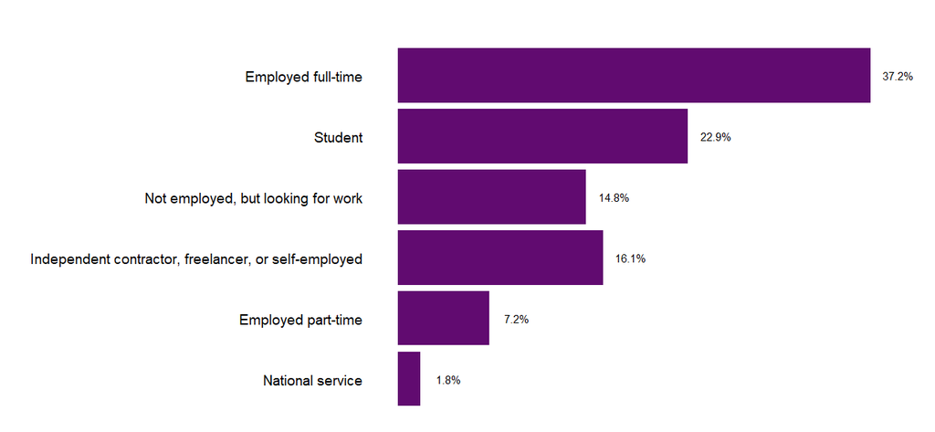

### Women only

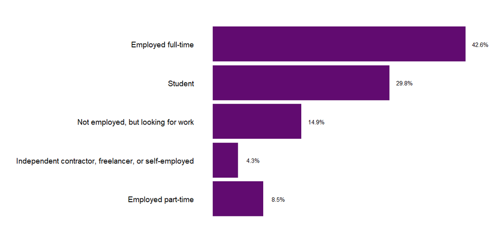

## Where do the developers come from?

### Region

Most respondents come from the greater Accra region. However, the extent of concentration in Accra seems to be larger for professional developers than for students.

### All Respondents

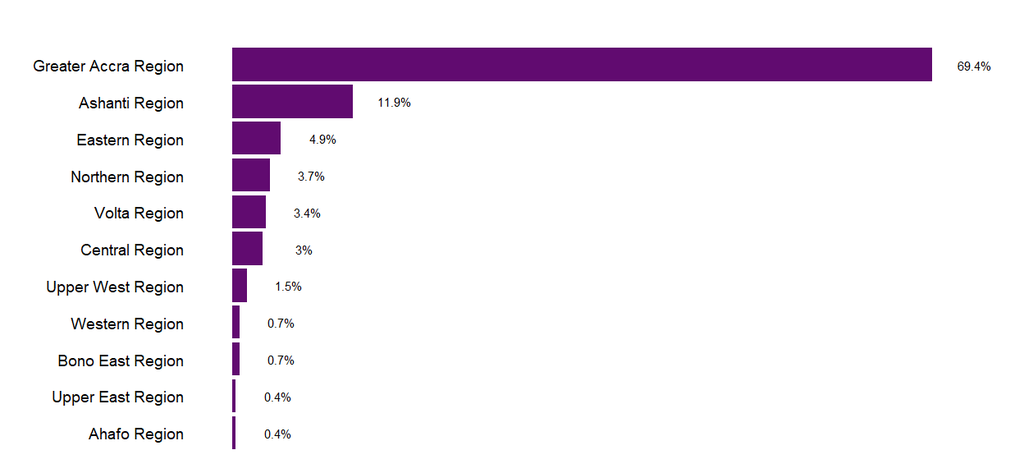

### Professional Developers

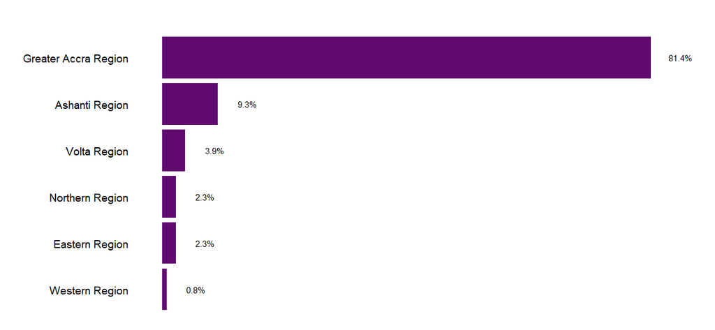

### Students

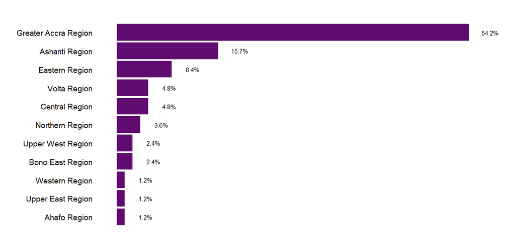

### City

Zoom in to get a more detailed picture.

Hover over the individual markers to see the professional status of the respondents.

[interactive chart not shown]

## How old are the respondents?

Most respondents are between 20 and 30.

While the students are very young in most cases, the professional developers display a little more variance in their ages. However, we have a very young sample at hand.

### All Respondents

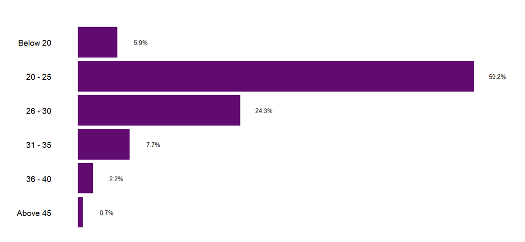

### Professional Developers

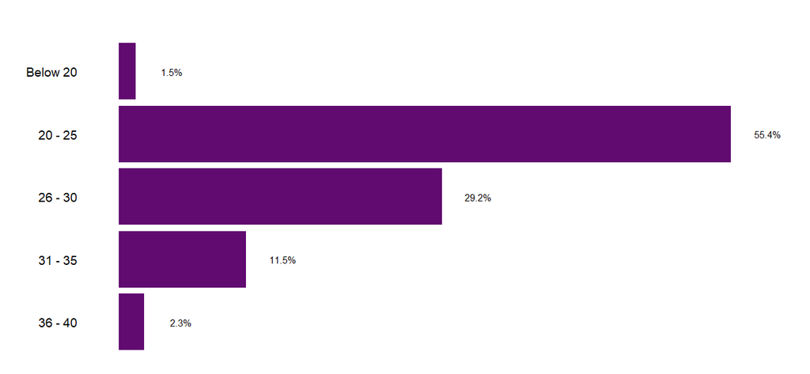

### Students

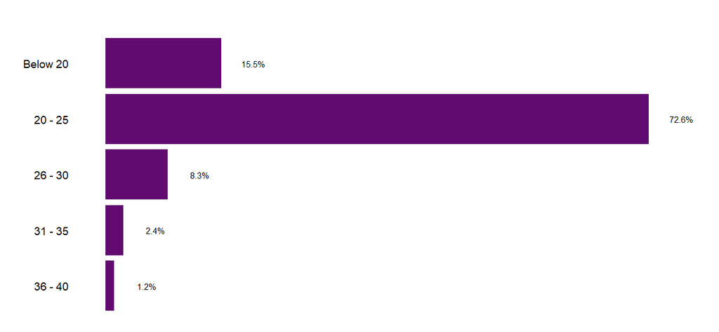

# Technology and Tech Culture

## How frequently do you learn a new language or framework?

### All Respondents

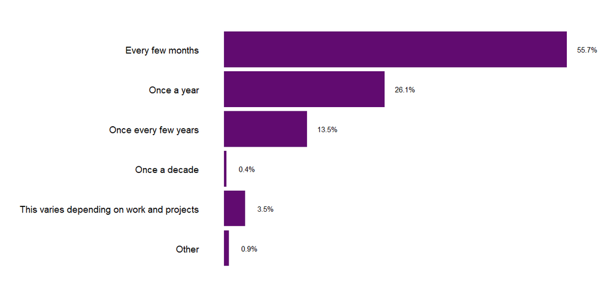

### Professional Developers

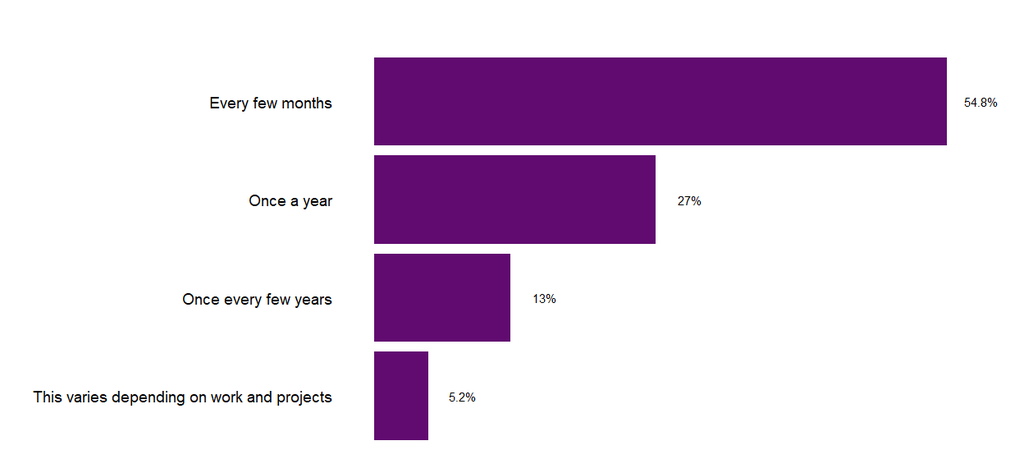

### Students

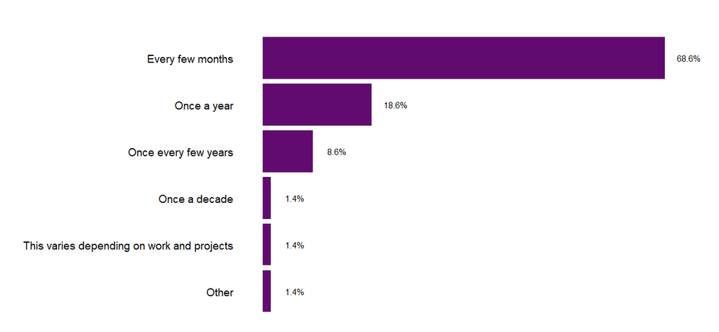

## Which programming, scripting and markup languages have you done extensive development work in over the past year?

*HTML/CSS* is the most used language, followed by *JavaScript*, *Python* and *SQL*. Professional developers are more likely to use *JavaScript* and *SQL*. *C++* and *C* are still widely useds to teach coding to students.

### All Respondents

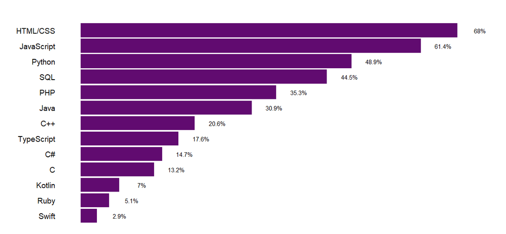

### Professional Developers

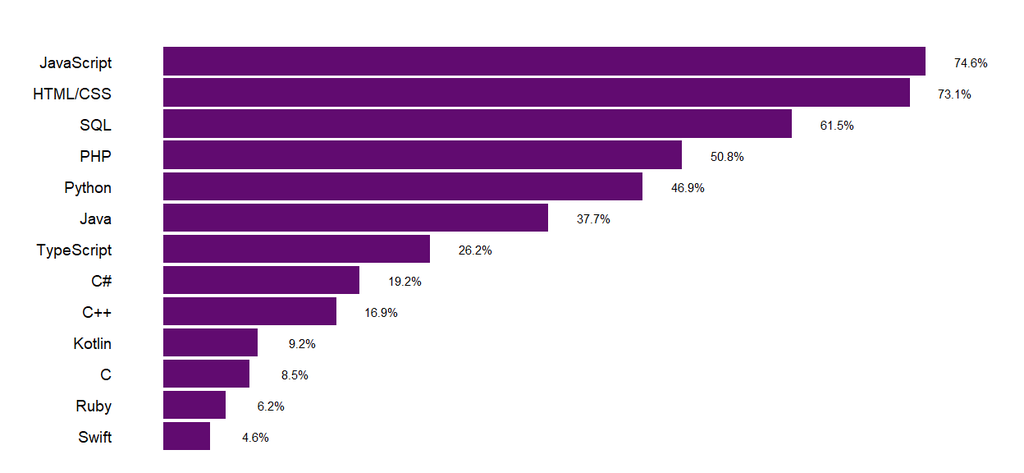

### Students

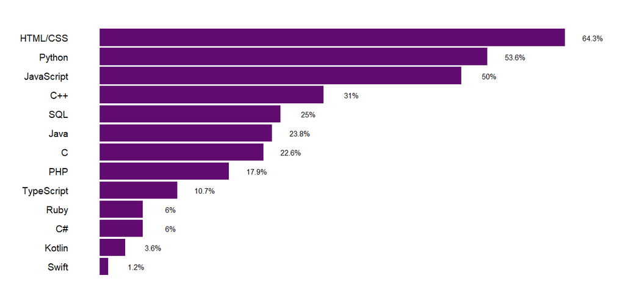

## Which platforms have you done extensive development work in over the past year?

### All Respondents

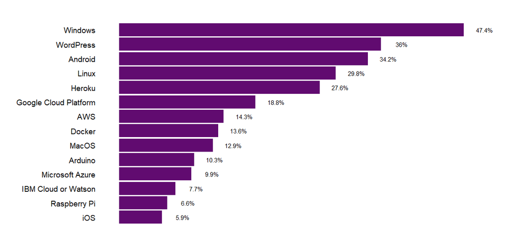

### Professional Developers

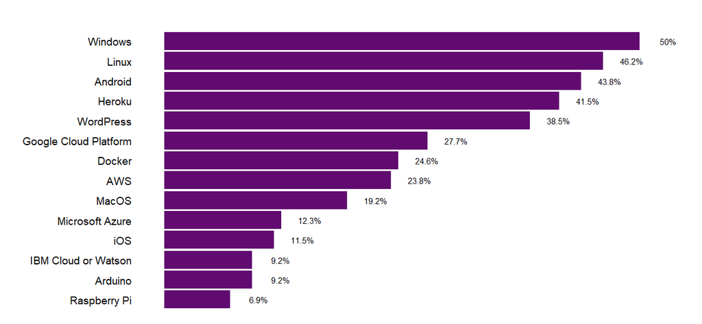

### Students

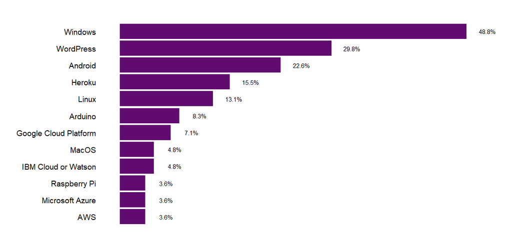

## Which web frameworks have you done extensive development work in over the past year?

*React.js* is the most popular web framework. BUT see next question…

### All Respondents

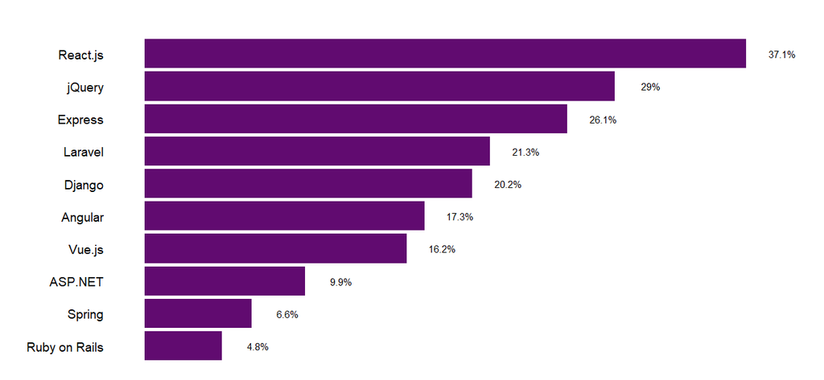

### Professional Developers

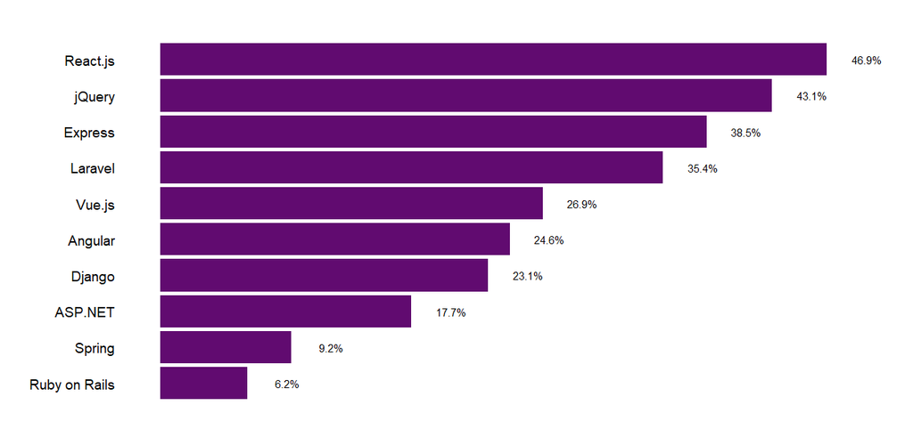

### Students

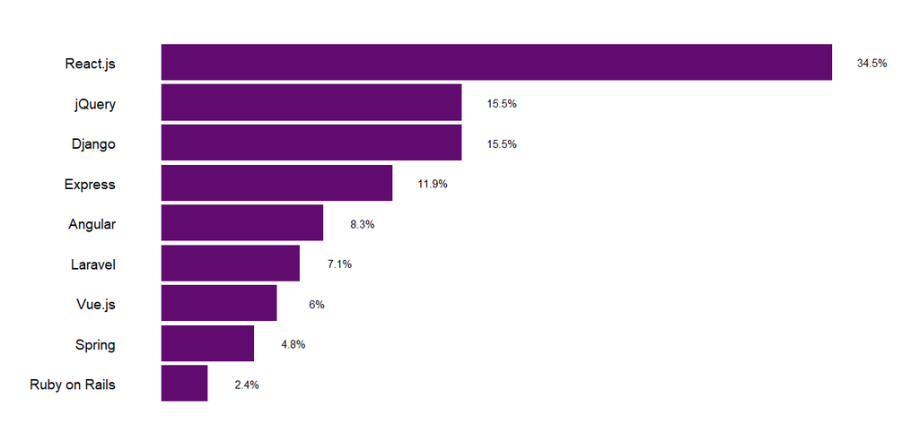

## Which other frameworks, libraries and tools have you done extensive development work in over the past year?

### All Respondents

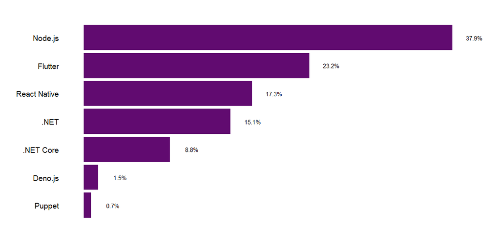

### Professional Developers

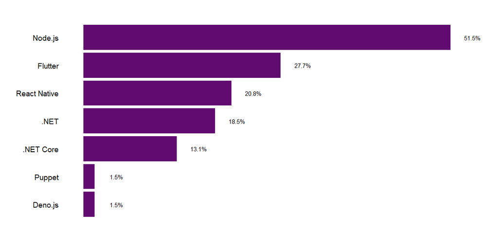

### Students

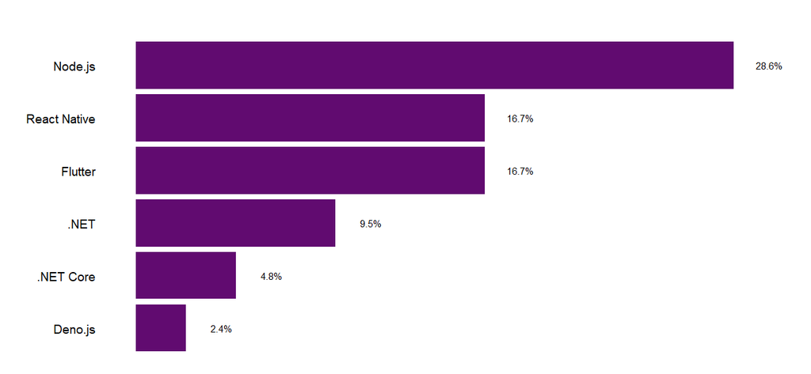

## Which collaborative tools have you done extensive development work in over the past year?

*GitHub* is by far the most popular version control tool. *Slack* is the most used business communication platform.

### All Respondents

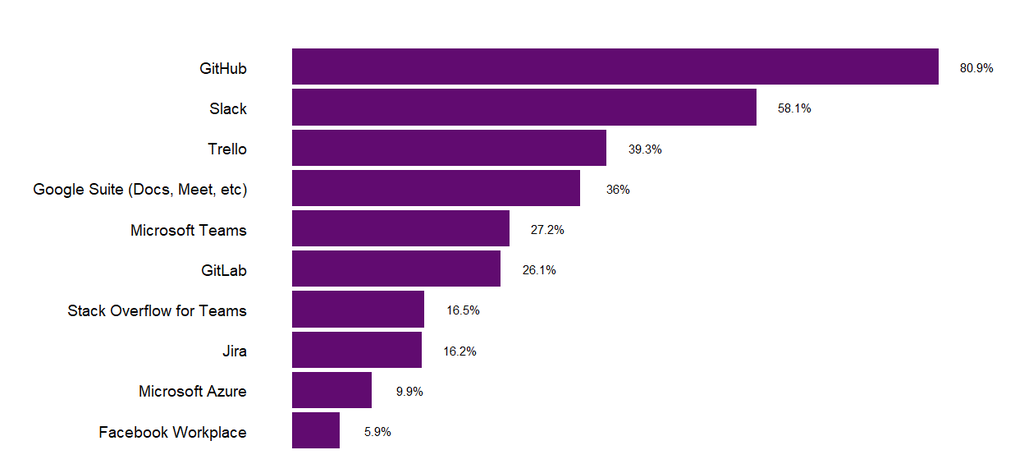

### Professional Developers

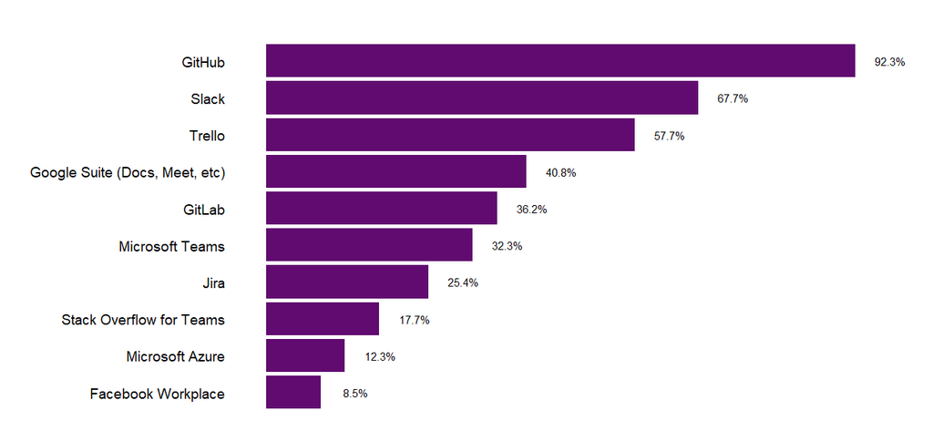

### Students

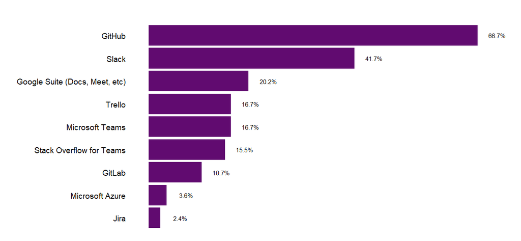